# [@dzidorius (Dzidas)](http://twitter.com/dzidorius)

Data mining and R language

# What is data mining?

- Discovery of new patterns
  - Cluster analysis
  - Anomaly detection
  - Rule mining
  - Regression
  - Summarization

# What is not data mining?

- Data management
- Data preprocessing
- Transformation
- Modeling / inference
- Visualization

# What is R language

- Pros
  - Open source
  - Community of millions of users and growing
  - Zillion of packages
  - Supports C++, Java, etc.
  - CLI
- Cons
  - Steep learning curve
  - In-memory

# Nearest neighbors

- Matlab
- Sas
- SPSS
- Stata
- Weka
- Python
- Mathematica
- MS Excel

# Github data example I

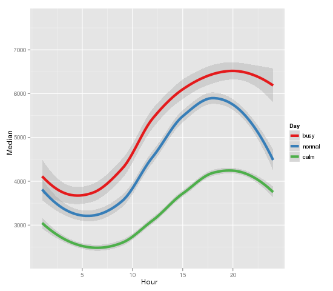

# Github data example II

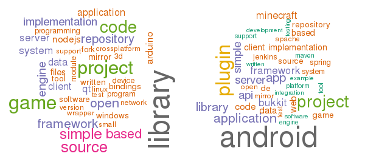

# Github data example III

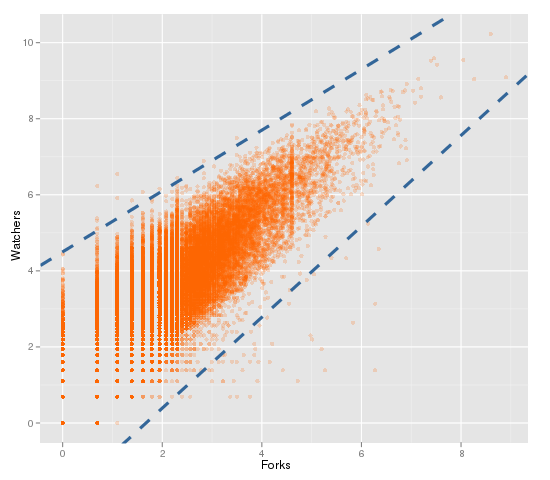

# Liquidation of big block of stocks

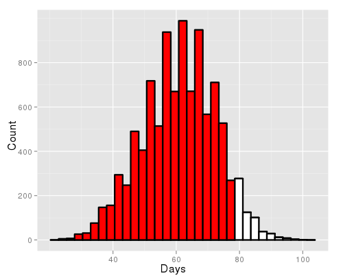

# Anomaly detection

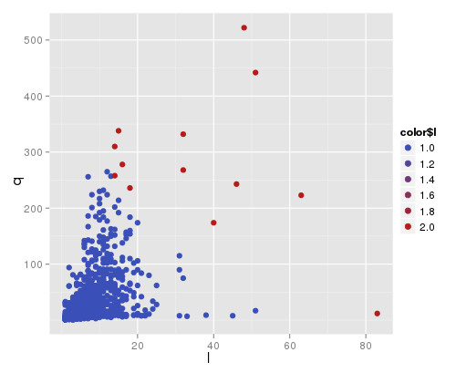

# Real estate mining

[figure not shown]

# Crime patterns

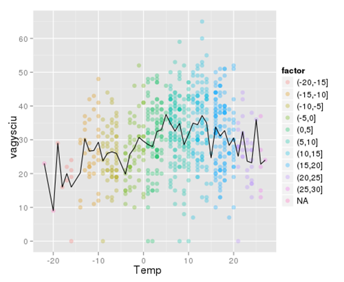

# Example of machine learning I

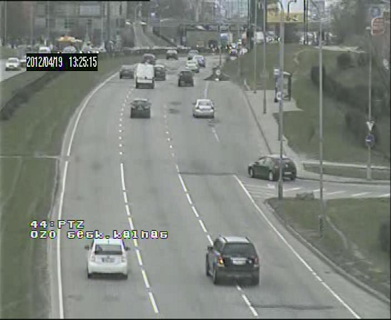

# Example of machine learning II

Positive

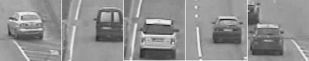

Negative

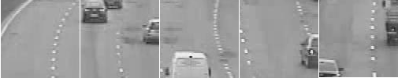

# Data sources

- Government
  - Data format - .pdf
  - Lagged data
  - Infrequent time-frame

# Public datasets

- [Amazon public dataset](http://aws.amazon.com/datasets?_encoding=UTF8&jiveRedirect=1)
  - Wikipedia
  - 1000 Genomes
  - Common Crawl Corpus
  - Google Books Ngrams
- [Google BigQuery](https://developers.google.com/bigquery/docs/overview)
  - GitHub
- Others
  - Wikileaks
  - Twitter
  - Facebook
  - Kaggle

# Data acquisition

- Web scraping (for ex.: Scrapy)
- RFID, public surveillance cameras
- Mobile phone(s)
- Honey spot as app., social network user

# Big data

- Size matters
  - I start forgetting things - 5 GB
  - I need to move a lot of data - 300 GB
  - I’m stuck - 1 TB
- Unstructured data - NoSql
- Real time

# Crunching big data - MapReduce

You and your 9 best friends are at National library. You are given 1 million of books and you need to find how many books have a title longer than 255 symbols?

- Divide randomly the books
- Separately, find all books matching the criteria and count them
- Get total answer

# Cyber security

- Misuse/Signature Detection
- Anomaly Detection
  - Supervised learning
  - Unsupervised Learning
- Hybrid Detection
- Scan Detection
- Profiling Modules

# Supervised learning

- Rule based
  - SNORT

# Unsupervised learning

- Clustering based
  - distance based (K-means, random Forest and etc.)
  - density based
- Rule based
  - based on user profiles

# Feature selection

- Basic features
  - source IP address
  - source port
  - destination IP address
  - destination port
  - protocol
  - flags
  - number of bytes
  - number of packets
- Derived features
  - time-window
  - connection window based features

# Who Am I?

Dzidorius Martinaitis

> Java, C++ and R developer & data junkie
- blog: investuotojas.eu
- twitter: [@dzidorius](http://www.twitter.com/dzidorius)
- github: kafka399
- linkedin: dzidorius